# Beer Breweries Data

Sanjee Yogeswaran

June 26, 2017

## Introduction

This is a case study on breweries and their ABV and IBU content. We explore the data for beer breweries around the United States, and particularly focus on alcoholic content and international bitterness units for these breweries.

The number of breweries in each state are as follows:

```r
## Code to read in GDP and Education tables
beers <- read.csv("data/Beers.csv",header=TRUE)
breweries <- read.csv("data/Breweries.csv",header=TRUE)
## Question 1:
##Code to count number of breweries in each state
table(breweries$State)
```

```
##
##  AK  AL  AR  AZ  CA  CO  CT  DC  DE  FL  GA  HI  IA  ID  IL  IN  KS  KY
##   7   3   2  11  39  47   8   1   2  15   7   4   5   5  18  22   3   4
##  LA  MA  MD  ME  MI  MN  MO  MS  MT  NC  ND  NE  NH  NJ  NM  NV  NY  OH
##   5  23   7   9  32  12   9   2   9  19   1   5   3   3   4   2  16  15
##  OK  OR  PA  RI  SC  SD  TN  TX  UT  VA  VT  WA  WI  WV  WY
##   6  29  25   5   4   1   3  28   4  16  10  23  20   1   4
```

The two tables are merged together, and the first six and last six entries are shown.

```r
## Question 2:
## Code to merge the two tables together
## Display first 6 rows and last 6 rows
mergedtables <- merge(beers,breweries, by.x=("Brewery_id"),by.y = ("Brew_ID"))
head(mergedtables,6)
```

```
##   Brewery_id        Name.x Beer_ID   ABV IBU
## 1          1  Get Together    2692 0.045  50
## 2          1 Maggie's Leap    2691 0.049  26
## 3          1    Wall's End    2690 0.048  19
## 4          1       Pumpion    2689 0.060  38
## 5          1    Stronghold    2688 0.060  25
## 6          1   Parapet ESB    2687 0.056  47
##                                 Style Ounces             Name.y
## 1                        American IPA     16 NorthGate Brewing
## 2                  Milk / Sweet Stout     16 NorthGate Brewing
## 3                   English Brown Ale     16 NorthGate Brewing
## 4                         Pumpkin Ale     16 NorthGate Brewing
## 5                     American Porter     16 NorthGate Brewing
## 6 Extra Special / Strong Bitter (ESB)     16 NorthGate Brewing
##          City State
## 1 Minneapolis    MN
## 2 Minneapolis    MN
## 3 Minneapolis    MN
## 4 Minneapolis    MN
## 5 Minneapolis    MN
## 6 Minneapolis    MN
```

```r
tail(mergedtables,6)
```

```
##      Brewery_id                    Name.x Beer_ID   ABV IBU
## 2405        556             Pilsner Ukiah      98 0.055  NA
## 2406        557  Heinnieweisse Weissebier      52 0.049  NA
## 2407        557           Snapperhead IPA      51 0.068  NA
## 2408        557         Moo Thunder Stout      50 0.049  NA
## 2409        557         Porkslap Pale Ale      49 0.043  NA
## 2410        558 Urban Wilderness Pale Ale      30 0.049  NA
##                        Style Ounces                        Name.y
## 2405         German Pilsener     12         Ukiah Brewing Company
## 2406              Hefeweizen     12       Butternuts Beer and Ale
## 2407            American IPA     12       Butternuts Beer and Ale
## 2408      Milk / Sweet Stout     12       Butternuts Beer and Ale
## 2409 American Pale Ale (APA)     12       Butternuts Beer and Ale
## 2410        English Pale Ale     12 Sleeping Lady Brewing Company
##               City State
## 2405         Ukiah    CA
## 2406 Garrattsville    NY
## 2407 Garrattsville    NY
## 2408 Garrattsville    NY
## 2409 Garrattsville    NY
## 2410     Anchorage    AK
```

The number of NAs in each column are displayed below:

```r
## Question 3:
##Count number of NAs in each column
colSums(is.na(mergedtables))
```

```
## Brewery_id     Name.x    Beer_ID        ABV        IBU      Style
##          0          0          0         62       1005          0
##     Ounces     Name.y       City      State
##          0          0          0          0
```

The median alcohol content and IBU of each state are shown below, along with bar graphs of each for comparison:

```r
## Question 4:
##Compute median alcohol content
abv <- tapply(mergedtables$ABV,mergedtables$State,median,na.rm=T)
abv
```

```
##     AK     AL     AR     AZ     CA     CO     CT     DC     DE     FL
## 0.0560 0.0600 0.0520 0.0550 0.0580 0.0605 0.0600 0.0625 0.0550 0.0570
##     GA     HI     IA     ID     IL     IN     KS     KY     LA     MA
## 0.0550 0.0540 0.0555 0.0565 0.0580 0.0580 0.0500 0.0625 0.0520 0.0540
##     MD     ME     MI     MN     MO     MS     MT     NC     ND     NE
## 0.0580 0.0510 0.0620 0.0560 0.0520 0.0580 0.0550 0.0570 0.0500 0.0560
##     NH     NJ     NM     NV     NY     OH     OK     OR     PA     RI
## 0.0550 0.0460 0.0620 0.0600 0.0550 0.0580 0.0600 0.0560 0.0570 0.0550
##     SC     SD     TN     TX     UT     VA     VT     WA     WI     WV
## 0.0550 0.0600 0.0570 0.0550 0.0400 0.0565 0.0550 0.0555 0.0520 0.0620
##     WY
## 0.0500
```

```r
##Compute median IBU
ibu <- tapply(mergedtables$IBU,mergedtables$State,median,na.rm=T)
ibu
```

```
##   AK   AL   AR   AZ   CA   CO   CT   DC   DE   FL   GA   HI   IA   ID   IL
## 46.0 43.0 39.0 20.5 42.0 40.0 29.0 47.5 52.0 55.0 55.0 22.5 26.0 39.0 30.0
##   IN   KS   KY   LA   MA   MD   ME   MI   MN   MO   MS   MT   NC   ND   NE
## 33.0 20.0 31.5 31.5 35.0 29.0 61.0 35.0 44.5 24.0 45.0 40.0 33.5 32.0 35.0
##   NH   NJ   NM   NV   NY   OH   OK   OR   PA   RI   SC   SD   TN   TX   UT
## 48.5 34.5 51.0 41.0 47.0 40.0 35.0 40.0 30.0 24.0 30.0   NA 37.0 33.0 34.0
##   VA   VT   WA   WI   WV   WY
## 42.0 30.0 38.0 19.0 57.5 21.0
```

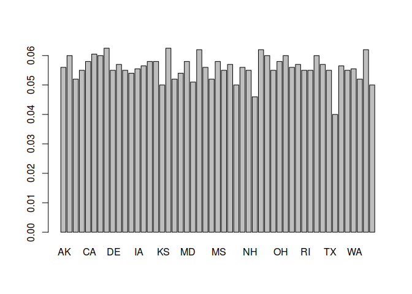

```r
##Plot bar graphs for ABV and IBU
library(ggplot2)
barplot(abv)
```

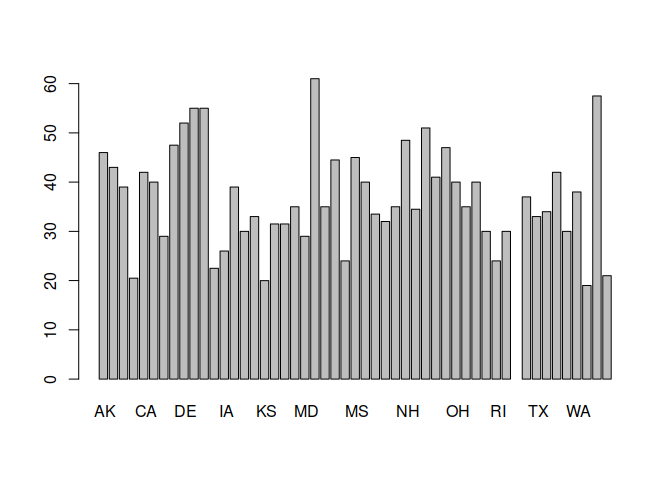

```r
barplot(ibu)
```

As seen above, the alcoholic beverage content does not vary significantly compared to the international bitterness units among the states.

The maximum values for ABV and IBU for each state and their respective values are printed below:

```r
## Question 5:
##Max values for ABV and IBU
which.max(abv)
```

```
##  DC
##   8
```

```r
max(abv)
```

```
## [1] 0.0625
```

```r
which.max(ibu)
```

```
##  ME
##  22
```

```r
max(ibu,na.rm=T)
```

```
## [1] 61
```

The summary statistics for ABV is printed here:

```r
## Question 6:
##Summary statistics for ABV
summary(abv)
```

```
##    Min. 1st Qu.  Median    Mean 3rd Qu.    Max.
## 0.04000 0.05500 0.05600 0.05585 0.05800 0.06250
```

The relationship between bitterness of beer and alcoholic content is explored here. A scatter plot is created as well as a linear regression model.

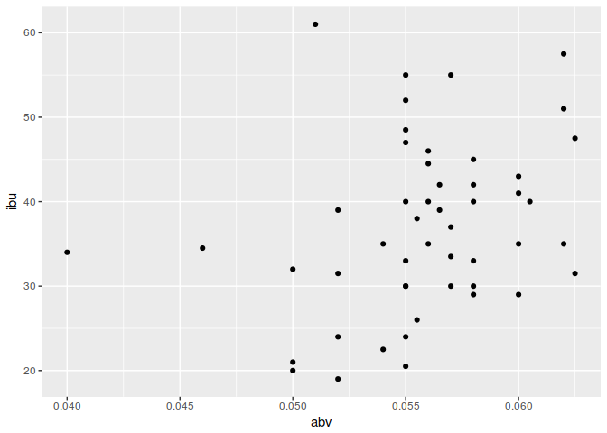

```r
##  Question 7:
##Plot abv vs ibu
qplot(abv,ibu)
```

There is a weak general positive trend shown in the scatter plot. The linear regression below explores this further.

```r
##Regression model
summary(lm(ibu ~ abv, data=mergedtables))
```

```
##
## Call:
## lm(formula = ibu ~ abv, data = mergedtables)
##
## Residuals:
##      Min       1Q   Median       3Q      Max
## -15.9578  -7.4750  -0.4837   5.6112  27.2548
##
## Coefficients:
##             Estimate Std. Error t value Pr(>|t|)
## (Intercept)  -0.8402    18.6174  -0.045   0.9642
## abv         678.1451   332.8898   2.037   0.0472 *
## ---
## Signif. codes:  0 '***' 0.001 '**' 0.01 '*' 0.05 '.' 0.1 ' ' 1
##
## Residual standard error: 9.842 on 48 degrees of freedom
##   (1 observation deleted due to missingness)
## Multiple R-squared:  0.07958,    Adjusted R-squared:  0.0604
## F-statistic:  4.15 on 1 and 48 DF,  p-value: 0.04717
```

```r
cor.test(ibu, abv)
```

```
##
##  Pearson's product-moment correlation
##
## data:  ibu and abv
## t = 2.0371, df = 48, p-value = 0.04717
## alternative hypothesis: true correlation is not equal to 0
## 95 percent confidence interval:
##  0.004066385 0.519640151
## sample estimates:
##       cor
## 0.2820948
```

The scatter plot shows a weak linear relationship between alcoholic beverage content and international bitterneess units. The adjusted r-squared value of 0.0604 reinforces that it is a weak correlation. The p-value generated in testing the linear model is 0.04, which shows that there is evidence to reject the null hypothesis that there is no correlation, however, since the value is close to 0.05, it shows it is a weak relationship.

## Conclusion

The data from brewieries in each state are analyzed in this case study. Two datasets are mergeda together and the total number of breweries in each state are displayed. The first six and last six entries in the merged tables are then displayed. Then the number of non available entries are shown. The median alcohol content and international bitterness units are calculated and plotted on a bar graph. The maximal values for the alcohol content and international bitterness units are found by state and their respective values. Then the summary statistics for alcoholic content is displayed. Finally a relationship between the international bitterness units and alcoholic content is explored through a scatter plot and a linear relationship.